# ClinSets: A Package for Multimodal Clinical Trials in Cancer Patients with a Focus on Immunotherapy

Farnoosh Abbas-Aghababazadeh, Yacine Bareche, Minoru Nakano, John Stagg and Benjamin Haibe-Kains

Bioinformatics and Computational Genomics Laboratory, Princess Margaret Cancer Center,University Health Network, Toronto, Ontario, Canada  
Faculty of Pharmacy, Université de Montréal, Montreal, Canada  
Centre de Recherche du Centre Hospitalier de l’Université de Montréal, Institut du Cancer de Montréal, Montreal, Canada  
Department of Medical Biophysics, University of Toronto, Toronto, Canada

benjamin.haibe.kains@utoronto.ca

10 November 2023

#### Abstract

# 1 Introduction

The ClinSets R data package provides a repository of multimodal clinical trials in cancer patients with focused on immunotherapy. Please refer to the manuscript URL (https://pubmed.ncbi.nlm.nih.gov/36055464/).

```r
library(stringr)
library(data.table)
library(kableExtra)
library(summarytools)
library(MultiAssayExperiment)
```

# 2 Load Immunotherapy Datasets

The following clinical immunotherapy datasets are also obtained from the a cloud-based [ORCESTRA](https://www.orcestra.ca/clinical_icb) platform to ensure that the curation and processing of the clinical genomic data are fully transparent and reproducible. The following datasets are used in the biomarker discovery for immunotherapy response via pan-cancer and cancer-specific analyses.

```r
app_dir <- str_split(rstudioapi::getActiveDocumentContext()$path,'ClinSets')[[1]][1]
dir <- file.path(app_dir, 'ClinSets', "data")
```

Table 1: Detailed overview for the immunotherapy datasets.

| Dataset | Discovery / Validation | Patients [#] | Cancer type | RECIST criteria | Clinical endpoints | Molecular data | PMID |
| --- | --- | --- | --- | --- | --- | --- | --- |
| Braun | Discovery | 181 | Kidney | Available | PFS/OS | RNA/DNA | [32472114](https://pubmed.ncbi.nlm.nih.gov/32472114/) |
| Gide | Validation | 41 | Melanoma | Available | PFS/OS | RNA | [30753825](https://pubmed.ncbi.nlm.nih.gov/30753825/) |
| Hugo | Discovery | 27 | Melanoma | Available | OS | RNA | [26997480](https://pubmed.ncbi.nlm.nih.gov/26997480/) |
| Hwang | Discovery | 21 | Lung | Available | PFS/OS | RNA | [31959763](https://pubmed.ncbi.nlm.nih.gov/31959763/) |
| Jerby_Arnon | Discovery | 112 | Melanoma | Available | PFS | RNA | [30388455](https://pubmed.ncbi.nlm.nih.gov/30388455/) |
| Jung | Discovery | 27 | Lung | Available | PFS | RNA/DNA | [31537801](https://pubmed.ncbi.nlm.nih.gov/31537801/) |
| Kim | Validation | 45 | Gastric | Available | None | RNA | [30013197](https://pubmed.ncbi.nlm.nih.gov/30013197/) |
| Limagne1 | Discovery | 70 | Lung | Available | PFS | RNA | [35051357](https://pubmed.ncbi.nlm.nih.gov/35051357/) |
| Limagne2 | Discovery | 26 | Lung | Available | PFS | RNA | [35051357](https://pubmed.ncbi.nlm.nih.gov/35051357/) |
| Liu | Discovery | 121 | Melanoma | Available | PFS/OS | RNA/DNA | [31792460](https://pubmed.ncbi.nlm.nih.gov/31792460/) |
| Miao1 | Discovery | 33 | Kidney | Available | PFS/OS | RNA/DNA | [29301960](https://pubmed.ncbi.nlm.nih.gov/29301960/) |
| Nathanson | Discovery | 24 | Melanoma | Available | OS | RNA/DNA | [27956380](https://pubmed.ncbi.nlm.nih.gov/27956380/) |
| Padron | Validation | 45 | Pancreas | Available | PFS/OS | RNA | [35662283](https://pubmed.ncbi.nlm.nih.gov/35662283/) |
| Puch | Validation | 55 | Melanoma | Available | None | RNA | [32472114](https://pubmed.ncbi.nlm.nih.gov/32472114/) |
| Riaz | Discovery | 46 | Melanoma | Available | OS | RNA/DNA | [29033130](https://pubmed.ncbi.nlm.nih.gov/29033130/) |
| Snyder | Discovery | 25 | Ureteral | Available | PFS/OS | RNA | [28552987](https://pubmed.ncbi.nlm.nih.gov/28552987/) |
| Van_Allen | Discovery | 42 | Melanoma | Available | PFS/OS | RNA/DNA | [26359337](https://pubmed.ncbi.nlm.nih.gov/26359337/) |
| VanDenEnde | Validation | 35 | Esophageal | Available | None | RNA | [33504550](https://pubmed.ncbi.nlm.nih.gov/33504550/) |
| Mariathasan | Discovery | 195 | Bladder | Available | OS | RNA/DNA | [29443960](https://pubmed.ncbi.nlm.nih.gov/31792460/) |
|  | Discovery | 67 | Kidney |  |  |  |  |
|  | Discovery | 26 | Lymph_node |  |  |  |  |
|  | Discovery | 26 | Ureteral |  |  |  |  |
| Total |  | ~1300 | Pan-cancer | [GitHub](https://github.com/bhklab/ClinSets.git) |  |  |  |

## 2.1 Data Curation Overview

We take data from published studies and curated them into standardized data objects to be used for integrated data analyses.

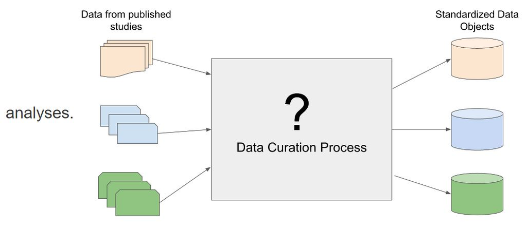

**Standardized data curation resolves inconsistencies across different datasets:**

- Various data formats: txt, csv, tsv, Excel, GEO…
- Various identifiers: “patientid” = “patient-id” = “id” = “patient” = “unique_patient_id”
- Unfriendly format: Newline characters, spaces, other unconventional characters
- Multiple data parts: patient/sample metadata, multiple assay data (RNA-seq, SNV…)

**The standardized data are integrated into MultiAssayExperiment object:**

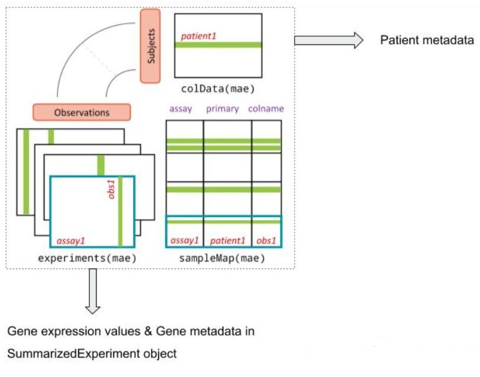

MultiAssayExperiment:

1. An R data object structure designed to hold multiple assay data for a set of patients/samples.
2. Assay data can be in other R data structures such as SummarizedExperiment.
3. Flexible: The data structure can handle assays with different number of observations.
4. Comes with functions to work with the data.

### 2.1.1 Data Curation Process

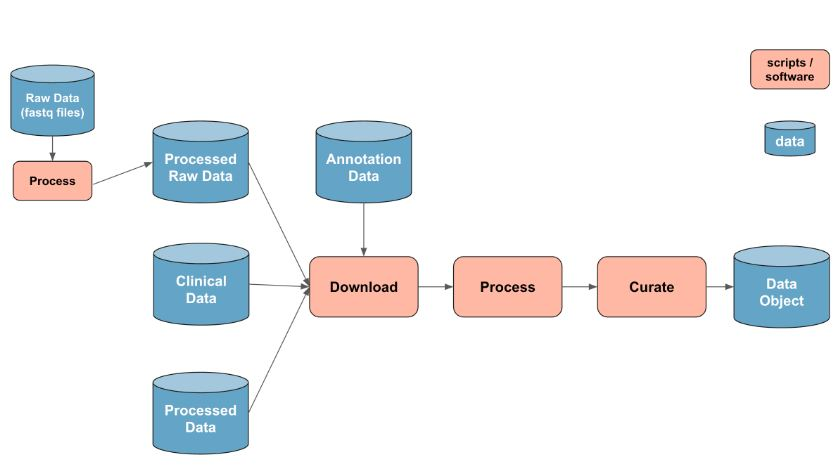

### 2.1.2 ORCESTRA: Platform to Manage Data Curation Pipeline Executions

The immunotherapy dataset curation pipelines were integrated and executed using the platform.

[figure not shown]

1. Each pipeline run is recorded and executed with a version controlled scripts.
2. Uses Snakemake to manage each step in a pipeline execution.
3. Establishes a clear association between the data and the version of code used to generate the data.
4. Provides a web interface to increase data accessibility. [www.orcestra.ca](https://www.orcestra.ca/)

### 2.1.3 Data Curation Example: VanDenEnde

The scripts uses immunotherapy_VanDenEnde data curation pipeline as an example. The rest of the datasets follow the same workflow.  
The pipeline is available in: ICB_VanDenEnde-snakemake  
There are common functions used across all immunotherapy dataset curation pipelines which are available in ICB_Common  
The pipeline is organized in 4 steps:

1. Downloads data from the publication source
2. Formats the downloaded data
3. Processes the formatted data into common data format across all immunotherapy datasets
4. Creates MultiAssayExperiment object

As an example, the Van_Allen (Melanoma) immunotherapy dataset with PMID [26359337](https://pubmed.ncbi.nlm.nih.gov/26359337/) includes RNA expression, clinical characteristics, and gene meta data. 42 patients have both clinical data and RNA expression data. In addition, the Van_Allen dataset has 20,242 protein-coding genes.

```r
app_dir <- str_split(rstudioapi::getActiveDocumentContext()$path,'ClinSets')[[1]][1]
dir <- file.path(app_dir, 'ClinSets', "data")

# gene expression, clinical characteristics, and gene meta data
load(file.path(dir, "ICB_Van_Allen__Melanoma__CTLA4.rda"))
expr <- assay(dat_icb)
clin <- colData(dat_icb) %>% as.data.frame()
annot <- rowData(dat_icb) %>% as.data.frame()

# number of protein-coding genes and patients
dim(expr)
```

```
## [1] 20242    42
```

```r
# summarizedExperiment class

print(dat_icb)
```

```
## class: SummarizedExperiment
## dim: 20242 42
## metadata(0):
## assays(1): gene_expression
## rownames(20242): TSPAN6 TNMD ... RP11-474G23.1 AC005358.1
## rowData names(12): source type ... gene_id_no_ver length
## colnames(42): Pat02 Pat03 ... Pat91 Pat98
## colData names(69): patientid sex ... nonresponse long.survival
```

The detailed clinical characteristics of the Van_Allen dataset including cancer type, age, sex, response (R vs. NR), overall survival (OS), and progression-free survival (PFS). The summary table represents that in the Van_Allen dataset less than 10% of the response data is missing, while no missing for survival variables. Additionally, almost 67% of patients are male. Note that “R” and “NR” represent responder and non-responder, respectively.

```r
# summary table of selected clinical variable
sub_clin <- clin[, c("age","sex", "response","survival_time_os", "survival_time_pfs")]

print(dfSummary(sub_clin,
                style = "grid",
                plain.ascii = FALSE,
                graph.col = FALSE),
      method = 'render')
```

Data Frame Summary

sub_clin

**Dimensions**: 42 x 5  
**Duplicates**: 0

| **No** | **Variable** | **Stats / Values** | **Freqs (% of Valid)** | **Valid** | **Missing** |
| --- | --- | --- | --- | --- | --- |
| 1 | age [integer] | Mean (sd) : 59.9 (15.4) min ≤ med ≤ max: 22 ≤ 61 ≤ 83 IQR (CV) : 24 (0.3) | 31 distinct values | 42 (100.0%) | 0 (0.0%) |
| 2 | sex [character] | 1. F 2. M | 14 ( 33.3% ) 28 ( 66.7% ) | 42 (100.0%) | 0 (0.0%) |
| 3 | response [character] | 1. NR 2. R | 30 ( 76.9% ) 9 ( 23.1% ) | 39 (92.9%) | 3 (7.1%) |
| 4 | survival_time_os [numeric] | Mean (sd) : 18.9 (16.2) min ≤ med ≤ max: 1.1 ≤ 12.8 ≤ 53.5 IQR (CV) : 27.8 (0.9) | 41 distinct values | 42 (100.0%) | 0 (0.0%) |
| 5 | survival_time_pfs [numeric] | Mean (sd) : 7.9 (10.3) min ≤ med ≤ max: 0.7 ≤ 2.8 ≤ 48.8 IQR (CV) : 7 (1.3) | 38 distinct values | 42 (100.0%) | 0 (0.0%) |

Generated by summarytools 1.0.1 ([R](https://www.r-project.org/) version 4.3.1)  
2023-11-10

# 3 References

# Appendix

Bareche, Y., Kelly, D., Abbas-Aghababazadeh, F., Nakano, M., Esfahani, P. N., Tkachuk, D., … & Stagg, J. (2022). Leveraging big data of immune checkpoint blockade response identifies novel potential targets. Annals of Oncology, 33(12), 1304-1317.